# 통계밥법론 Chap5_후반부 실습코드

## 5.8.1 Normal Probability Plots

qqplot은 분석하는 변수가 정규분포로부터 추출되었는지 확인할 수 있는 방법이다.  
분포의 분위수를 이용하여 값을 계산하고 그 값을 plot을 통해 나타낸다.  
plot의 패턴이 근사적으로 직선을 따르면 데이터가 정규분포로부터 추출되었다고 할 수 있다.

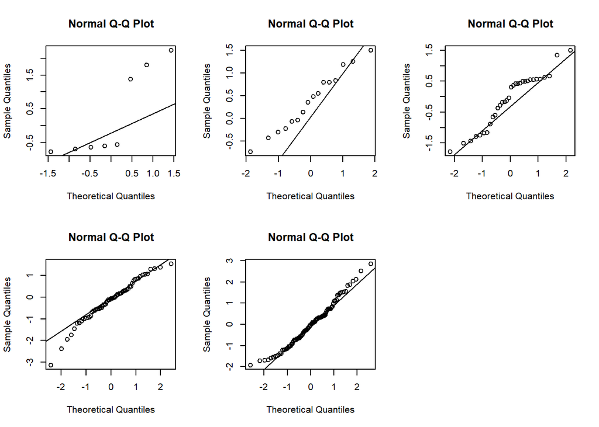

```r
n=c(8,16,32,64,100)
par(mfrow=c(2,3))
for (y in n){
  qqnorm(rnorm(y))
  qqline(rnorm(y))
}
```

정규분포를 이용해서 난수를 생성한 결과,  
표본의 크기가 커질수록 패턴이 직선에 가까운 형태를 갖는 것을 알 수 있다.

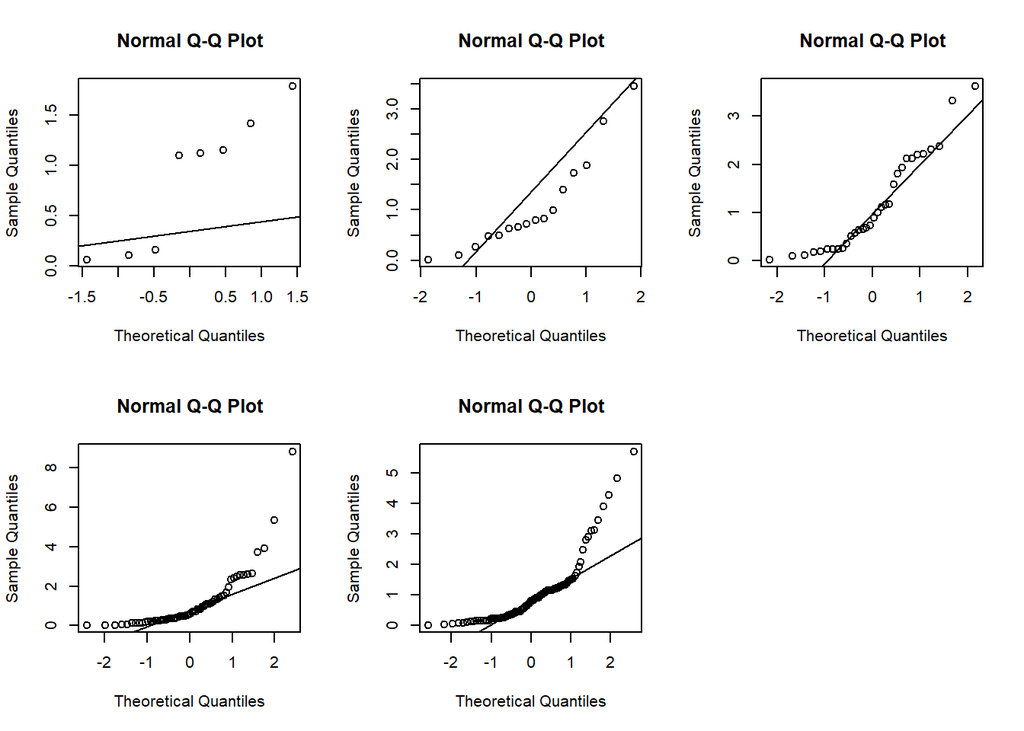

```r
n=c(8,16,32,64,100)
par(mfrow=c(2,3))
for (y in n){
  qqnorm(rexp(y))
  qqline(rexp(y))
}
```

지수분포를 이용해서 난수를 생성한 결과,  
표본의 크기가 커질수록 직선에 약간 가까워 지지만 정규분포만큼 뚜렷한 직선 패턴을 보이지는 않는다.

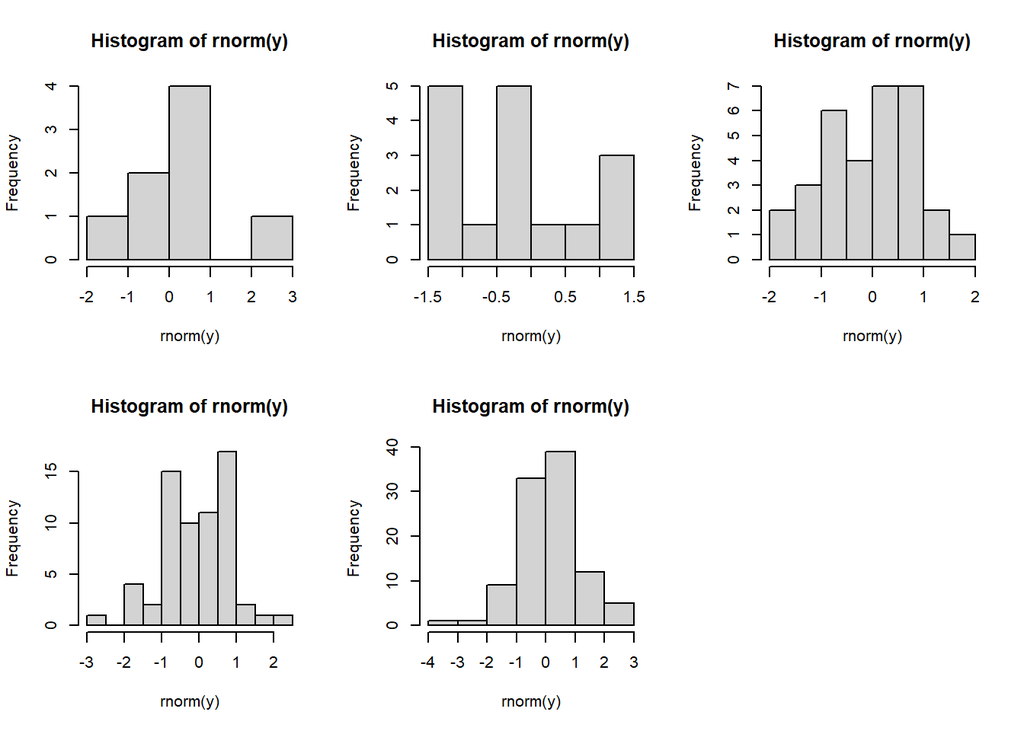

```r
n=c(8,16,32,64,100)
par(mfrow=c(2,3))
for (y in n){
  hist(rnorm(y))
}
```

히스토그램을 통해서도 표본이 늘어날수록 정규분포의 종 모양에 가까워지는 것을 확인할 수 있다.

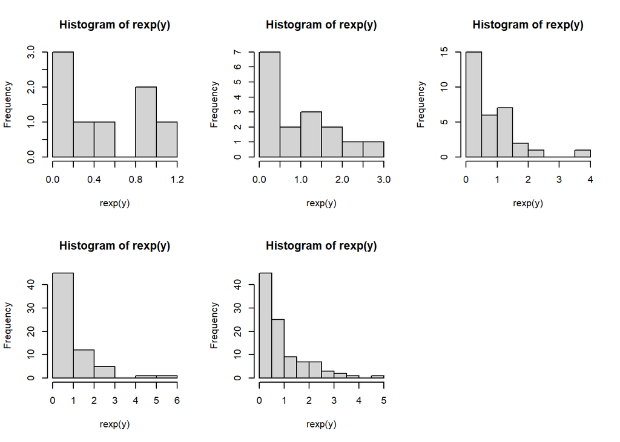

```r
n=c(8,16,32,64,100)
par(mfrow=c(2,3))
for (y in n){
  hist(rexp(y))
}
```

지수분포를 이용해 추출한 표본에서는 크기가 늘어나도 정규분포에 가까운 종 모양이 보이지 않는다.

## 5.9 Kolmogorov–Smirnov Goodness-of-Fit Tests

## 5.9.1 Example—Kolmogorov–Smirnov Goodness-of-Fit Test

```r
rt5 <- rt(300,df=5)
rnn <- rnorm(300)
ks.test(rt5,function(x) pt(x,df=2))
```

```
##
##  One-sample Kolmogorov-Smirnov test
##
## data:  rt5
## D = 0.075897, p-value = 0.0631
## alternative hypothesis: two-sided
```

```r
ks.test(rnn,function(x) pt(x,df=2))
```

```
##
##  One-sample Kolmogorov-Smirnov test
##
## data:  rnn
## D = 0.09309, p-value = 0.01104
## alternative hypothesis: two-sided
```

```r
ks.test(rt5,rnn)
```

```
##
##  Two-sample Kolmogorov-Smirnov test
##
## data:  rt5 and rnn
## D = 0.1, p-value = 0.09956
## alternative hypothesis: two-sided
```

## EDF GOF Tests

- The Kolmogorov-Smirnov metric(`lillie.test`)
- The Cramer-von-Mises meric(`cvm.test`)
- The Anderson-Darling metric(`ad.test`)

`lillie.test`의 경우 `nortest`라는 패키지를 통해 불러올 수 있다.  
`cvm.test`, `ad.test`는 `nortest`, `goftest` 두 패키지에서 모두 불러올 수 있다.  
또한 goftest를 이용해서 cvm.test, ad.test를 진행하여 `estimated = TRUE`값을 지정할 경우,  
파라미터에 대한 추정값과 같이 출력해준다.

## 필요한 패키지인 `nortest`, `goftest` 설치

```r
# install.packages("nortest")
# install.packages("goftest")
library(nortest)
library(goftest)
```

## 정규분포에서 랜덤 난수 추출

```r
set.seed(10)
X1 <- rnorm(10,mean=2,sd=1)
X2 <- rnorm(20,mean=2,sd=1)
X3 <- rnorm(30,mean=2,sd=1)
```

표본의 크기가 달라질 때, 변하는 정도를 확인하기 위해 3개의 랜덤 정규표본 난수를 생성하였다.

## The kolmogorov-Sminov metric by using nortset package

```r
nortest::lillie.test(X1)
```

```
##
##  Lilliefors (Kolmogorov-Smirnov) normality test
##
## data:  X1
## D = 0.17198, p-value = 0.5491
```

```r
nortest::lillie.test(X2)
```

```
##
##  Lilliefors (Kolmogorov-Smirnov) normality test
##
## data:  X2
## D = 0.10747, p-value = 0.7883
```

```r
nortest::lillie.test(X3)
```

```
##
##  Lilliefors (Kolmogorov-Smirnov) normality test
##
## data:  X3
## D = 0.079722, p-value = 0.8967
```

## The Cramer-von-Mises meric by using nortest package

```r
nortest::cvm.test(X1)
```

```
##
##  Cramer-von Mises normality test
##
## data:  X1
## W = 0.053122, p-value = 0.4301
```

```r
nortest::cvm.test(X2)
```

```
##
##  Cramer-von Mises normality test
##
## data:  X2
## W = 0.038197, p-value = 0.6977
```

```r
nortest::cvm.test(X3)
```

```
##
##  Cramer-von Mises normality test
##
## data:  X3
## W = 0.020221, p-value = 0.9635
```

## The Cramer-von-Mises meric by using goftest package

```r
goftest::cvm.test(X1,"pnorm",mean(X1),sd=sd(X1))
```

```
##
##  Cramer-von Mises test of goodness-of-fit
##  Null hypothesis: Normal distribution
##  with parameter sd = 0.699893509643704
##  Parameters assumed to be fixed
##
## data:  X1
## omega2 = 0.053122, p-value = 0.8681
```

```r
goftest::cvm.test(X2,"pnorm",mean(X2),sd=sd(X2))
```

```
##
##  Cramer-von Mises test of goodness-of-fit
##  Null hypothesis: Normal distribution
##  with parameter sd = 0.947672798832273
##  Parameters assumed to be fixed
##
## data:  X2
## omega2 = 0.038197, p-value = 0.9464
```

```r
goftest::cvm.test(X3,"pnorm",mean(X3),sd=sd(X3))
```

```
##
##  Cramer-von Mises test of goodness-of-fit
##  Null hypothesis: Normal distribution
##  with parameter sd = 0.947887463535685
##  Parameters assumed to be fixed
##
## data:  X3
## omega2 = 0.020221, p-value = 0.9973
```

```r
goftest::cvm.test(X3,"pnorm",mean=mean(X3),sd=sd(X3),estimated = TRUE)
```

```
##
##  Cramer-von Mises test of goodness-of-fit
##  Braun's adjustment using 5 groups
##  Null hypothesis: Normal distribution
##  with parameters mean = 1.88713294273152, sd = 0.947887463535685
##  Parameters assumed to have been estimated from data
##
## data:  X3
## omega2max = 0.10696, p-value = 0.9846
```

## The Anderson-Darling metric by using nortest package

```r
nortest::ad.test(X1)
```

```
##
##  Anderson-Darling normality test
##
## data:  X1
## A = 0.32467, p-value = 0.4574
```

```r
nortest::ad.test(X2)
```

```
##
##  Anderson-Darling normality test
##
## data:  X2
## A = 0.32419, p-value = 0.5035
```

```r
nortest::ad.test(X3)
```

```
##
##  Anderson-Darling normality test
##
## data:  X3
## A = 0.13785, p-value = 0.9726
```

## The Anderson-Darling metric by using goftest package

```r
goftest::ad.test(X1,"pnorm",mean(X1),sd=sd(X1))
```

```
##
##  Anderson-Darling test of goodness-of-fit
##  Null hypothesis: Normal distribution
##  with parameter sd = 0.699893509643704
##  Parameters assumed to be fixed
##
## data:  X1
## An = 0.32467, p-value = 0.9169
```

```r
goftest::ad.test(X2,"pnorm",mean(X2),sd=sd(X2))
```

```
##
##  Anderson-Darling test of goodness-of-fit
##  Null hypothesis: Normal distribution
##  with parameter sd = 0.947672798832273
##  Parameters assumed to be fixed
##
## data:  X2
## An = 0.32419, p-value = 0.918
```

```r
goftest::ad.test(X3,"pnorm",mean(X3),sd=sd(X3))
```

```
##
##  Anderson-Darling test of goodness-of-fit
##  Null hypothesis: Normal distribution
##  with parameter sd = 0.947887463535685
##  Parameters assumed to be fixed
##
## data:  X3
## An = 0.13785, p-value = 0.9993
```

```r
goftest::ad.test(X3,"pnorm",mean=mean(X3),sd=sd(X3),estimated = TRUE)
```

```
##
##  Anderson-Darling test of goodness-of-fit
##  Braun's adjustment using 5 groups
##  Null hypothesis: Normal distribution
##  with parameters mean = 1.88713294273152, sd = 0.947887463535685
##  Parameters assumed to have been estimated from data
##
## data:  X3
## Anmax = 1.2882, p-value = 0.7384
```

분석결과, lillie.test는 표본이 작을 때는 유의확률이 cvm.test,ad.test에 비해서는 높지만,  
표본이 커질수록 cvm.test와 ad.test의 유의확률이 더 높아지는 것을 확인할 수 있다.

또한 goftest의 패키지를 통해 cvm.test와 ad.test를 이용할 경유 유의확률이 nortest 패키지에 비해서  
현저히 증가하는 것을 볼 수 있다.

조금 더 엄격한 정규성 검정이 필요할 경우, goftest보다 nortest 패키지를 이용하는 것이 좋다고 판단된다.